# Kaggle - House Price Prediction - Feature Exploration

2017-09-23

# Introduction

Ask a home buyer to describe their dream house, and they probably won’t begin with the height of the basement ceiling or the proximity to an east-west railroad. But this playground competition’s dataset proves that much more influences price negotiations than the number of bedrooms or a white-picket fence.

With 79 explanatory variables describing (almost) every aspect of residential homes in Ames, Iowa, this competition challenges to predict the final price of each home.

This kernel aims at exploration of each 79 features.

## Loading all Required libraries

- **Rmisc** : For multiplot function
- **ggplot2** : For plots
- **dplyr, tidyr, data.table** : For data operations
- **knitr** : To kneet html

```r
library(Rmisc)
library(ggplot2)
library(ggforce)
library(dplyr)
library(tidyr)
library(data.table)
library(knitr)
```

## Functions to plot factor and continous variables

Creating common function using ggplot and multiplot to explore factor features and continous numeric features. This function will take three arguments - dataframe, x variable and y variable(target).

- **factorchart** : Returns three charts : boxplot, bar chart for count and bar chart for mean of target

```r
factorChart <- function (df, val1, val2) {
  p1 <- ggplot(df, aes(x = as.factor(df[[val1]]), y = df[[val2]], fill =  as.factor(df[[val1]]))) +
    geom_boxplot() +
    theme(legend.position = "none") +
    labs(x = "", y = val2)+
    theme(axis.text.x = element_text(angle = 45, hjust = 1)) +
    scale_y_continuous(labels = scales::comma)

  p2 <- ggplot(df, aes(x = as.factor(df[[val1]]), fill =  as.factor(df[[val1]]))) +
    geom_bar() +
    geom_text(stat = "count", aes(label =..count..), vjust = -0.5) +
    theme(legend.position = "none")+
    labs(x = val1)+
    theme(axis.text.x = element_text(angle = 45, hjust = 1))

  p3 <- ggplot(df, aes(x = as.factor(df[[val1]]), y = df[[val2]],  fill =  as.factor(df[[val1]]))) +
    geom_bar(stat = "summary", fun.y = "mean") +
    theme(legend.position = "none")+
    labs(x = val1, y = "Mean") +
    theme(axis.text.x = element_text(angle = 45, hjust = 1)) +
    scale_y_continuous(labels = scales::comma)


  layout <- matrix(c(1,1,1,1,2,2,3,3),2,4,byrow=TRUE)
  multiplot(p1, p2, p3, layout=layout)
}
contChart <- function (df, val1, val2) {
p1 <- ggplot(df, aes(x = train[[val1]], y = ..density..)) +
      geom_histogram(fill = "red", alpha = 0.2, color = "black") +
      geom_density(fill = "green", alpha = 0.2)+
      labs(x = val1)
p2 <- ggplot(df, aes(x = df[[val1]], y = df[[val2]])) +
      geom_point(color = "red", alpha = 0.3) +
      geom_smooth(method = "lm")+
    labs(x = val1, y = val2)+
    scale_y_continuous(labels = scales::comma)
layout <- matrix(c(1,2), 1, 2, byrow=TRUE)
multiplot(p1, p2, layout=layout)
}
```

## Load Data

We are using **fread** function to read train and test csv files. fread is easiest and one of the most powerful function to load data(except excel)

```r
setwd("D:/Kaggle/House Prices Advanced Regression Techniques")
train <- fread("train.csv", stringsAsFactors = TRUE)
test <- fread("test.csv", stringsAsFactors = TRUE)
```

## Data Overview

Let’s look at few sample records first

```r
kable(head(train))
```

[output not shown]

Train got 1460 observations and 81 variables. Test got 80 variables(excluding target variable - SalePrice)

## Missing Values

Let’s look at columns with some missing values

```r
train_nulls <- as.data.frame(colSums(is.na(train)))#as.data.frame(sapply(X = train, FUN = function(x) sum(is.na(x))))
train_nulls <- add_rownames(train_nulls, "Column")
```

```
Deprecated, use tibble::rownames_to_column() instead.
```

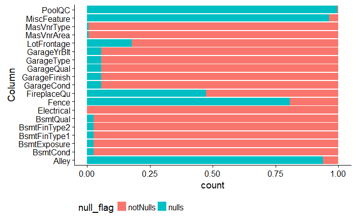

```r
colnames(train_nulls)[2] <- "nulls"
train_nulls$notNulls = nrow(train) - train_nulls$nulls
train_nulls %>%
  filter(nulls > 0) %>%
  gather("null_flag", "count", -Column) %>%
  ggplot(aes(x = Column, y = count, fill = null_flag)) +
  geom_bar(stat = "identity",position = "fill") +
  theme(legend.position = "bottom") +
  coord_flip()
```

Few features get almost 100% null values. e.g. poolqc. Probably null poolqc means no pool. It will lbe meaningful. We will impute null values after exploring each feature

## Exploring Each Feature

### MSSubClass

As per data dictonary:

**MSSubClass:** Identifies the type of dwelling involved in the sale.

```
    20  1-STORY 1946 & NEWER ALL STYLES
    30  1-STORY 1945 & OLDER
    40  1-STORY W/FINISHED ATTIC ALL AGES
    45  1-1/2 STORY - UNFINISHED ALL AGES
    50  1-1/2 STORY FINISHED ALL AGES
    60  2-STORY 1946 & NEWER
    70  2-STORY 1945 & OLDER
    75  2-1/2 STORY ALL AGES
    80  SPLIT OR MULTI-LEVEL
    85  SPLIT FOYER
    90  DUPLEX - ALL STYLES AND AGES
   120  1-STORY PUD (Planned Unit Development) - 1946 & NEWER
   150  1-1/2 STORY PUD - ALL AGES
   160  2-STORY PUD - 1946 & NEWER
   180  PUD - MULTILEVEL - INCL SPLIT LEV/FOYER
   190  2 FAMILY CONVERSION - ALL STYLES AND AGES
```

Although we read it as integer but it is actually a factor.

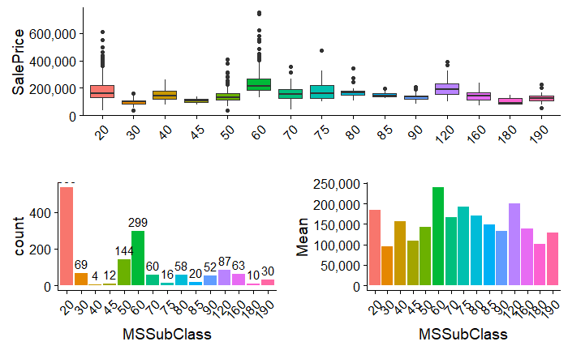

```r
factorChart(train, "MSSubClass", "SalePrice")
```

**Conclusion:** Looks promosing feature with clear distinction between top 2 categories - 1 story and 2 story

### MSZoning

As per data dictonary: **MSZoning:** Identifies the general zoning classification of the sale.

```
   A    Agriculture
   C    Commercial
   FV   Floating Village Residential
   I    Industrial
   RH   Residential High Density
   RL   Residential Low Density
   RP   Residential Low Density Park
   RM   Residential Medium Density
```

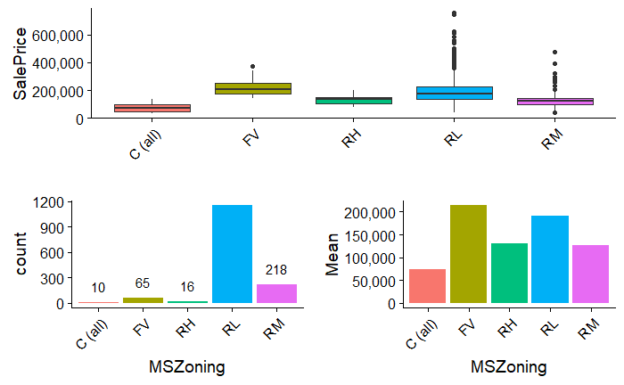

```r
factorChart(train, "MSZoning", "SalePrice")
```

**Conclusion:** Most of the values belong to Residential low and medium density. Boxplot also suggest good distinction between those. Mean too suggests same thing. Good Feature.

### LotFrontage

**LotFrontage:** Linear feet of street connected to property.

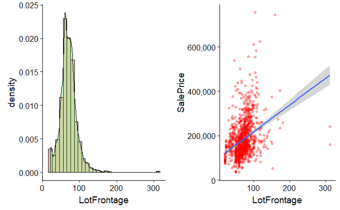

```r
contChart(train, "LotFrontage", "SalePrice")
```

**Conclusion:** Most of the frountage values are between 0 to 100. Good linear relation ship with target variable.

### LotArea

**LotArea:** Lot size in square feet - Probably most important feature. Let’s check

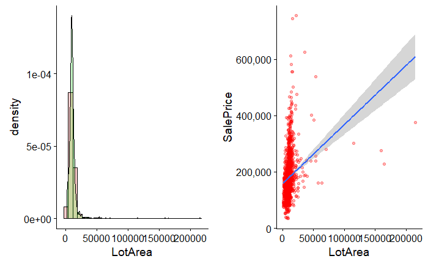

```r
contChart(train, "LotArea", "SalePrice")
```

Unfortunately our custom made function not giving valuable information due to outliers. Let’s try again by zooming desne values.

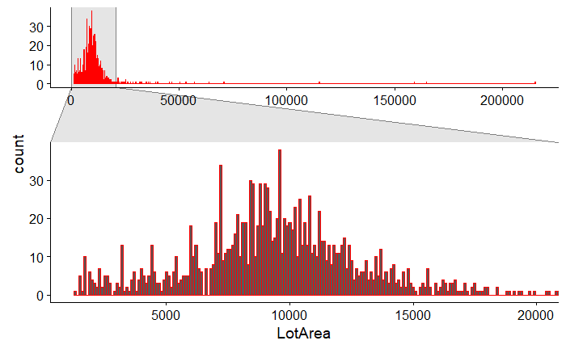

```r
train %>%
  ggplot(aes(x = LotArea)) +
  geom_histogram(color = "red", binwidth = 100) +
  facet_zoom(x = (LotArea >0 & LotArea < 20000))
```

```r
NA
```

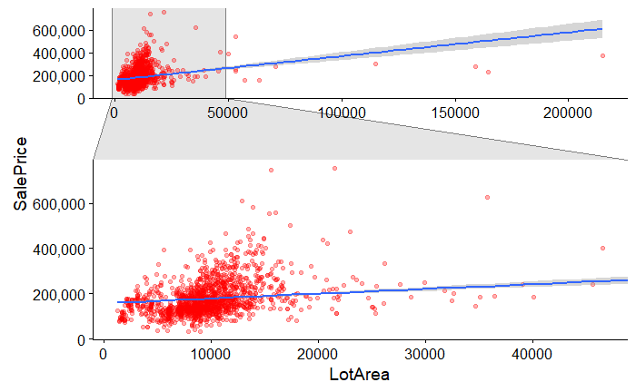

```r
train %>%
  ggplot(aes(x = LotArea, y = SalePrice)) +
      geom_point(color = "red", alpha = 0.3) +
      geom_smooth(method = "lm")+
    scale_y_continuous(labels = scales::comma)+
  facet_zoom(x = (LotArea >0 & LotArea < 50000))
```

```r
NA
```

### Street

**Street:** Type of road access to property

```
   Grvl Gravel
   Pave Paved
```

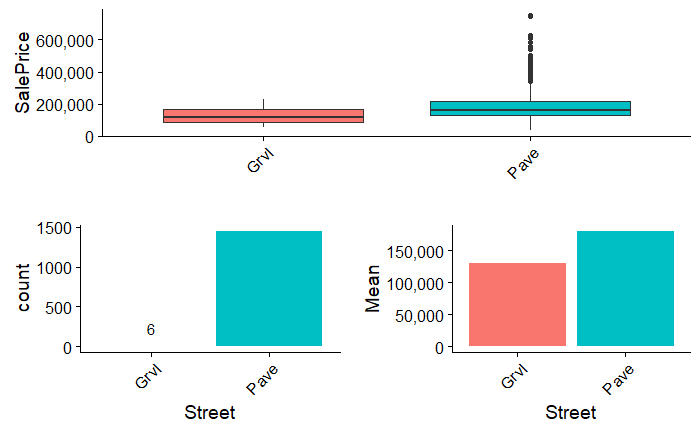

```r
factorChart(train, "Street", "SalePrice")
```

**Conclusion:** Almost all values belong to Pave streets. Not useful.

### Alley

**Alley:** Type of alley access to property

```
   Grvl Gravel
   Pave Paved
   NA   No alley access
```

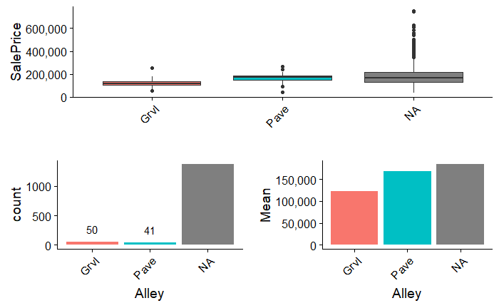

```r
factorChart(train, "Alley", "SalePrice")
```

**Conclusion:** Most of the homes are with no Alley. Acutally we can impute NA with some meaningful value.

### LotShape

**LotShape:** General shape of property

```
   Reg  Regular
   IR1  Slightly irregular
   IR2  Moderately Irregular
   IR3  Irregular
```

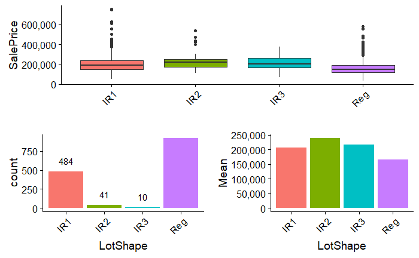

```r
factorChart(train, "LotShape", "SalePrice")
```

** Conclusion :** Moderately Irregular lot should fetch lesser price than slightly irregular lot. However it is not the case here. Probably because IR2 and IR3 got very small number of observations. It is also possible that Lotsize masking this fact. So let’s use prize per square feet instead of SalePrice.

```r
train$psf <- train$SalePrice / train$LotArea
```

### LandContour

**LandContour:** Flatness of the property

```
   Lvl  Near Flat/Level
   Bnk  Banked - Quick and significant rise from street grade to building
   HLS  Hillside - Significant slope from side to side
   Low  Depression
```

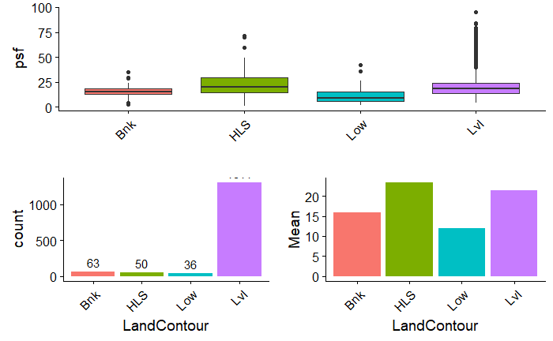

```r
factorChart(train, "LandContour", "psf")
```

**Conclusion:** Most of the houses are near flat. Ofcourse Hill side got more value than depression one.

### Utilities

**Utilities:** Type of utilities available

```
       AllPub   All public Utilities (E,G,W,& S)
   NoSewr   Electricity, Gas, and Water (Septic Tank)
   NoSeWa   Electricity and Gas Only
   ELO  Electricity only
```

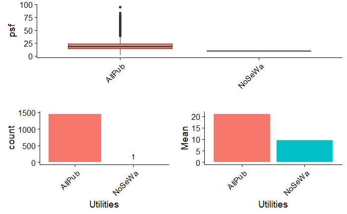

```r
factorChart(train, "Utilities", "psf")
```

**Conclusion:** Not at all useful. Very much skewed. Almost all house got all publice utilities except one.

### LotConfig:

**Lot configuration:**

```
   Inside   Inside lot
   Corner   Corner lot
   CulDSac  Cul-de-sac
   FR2  Frontage on 2 sides of property
   FR3  Frontage on 3 sides of property
```

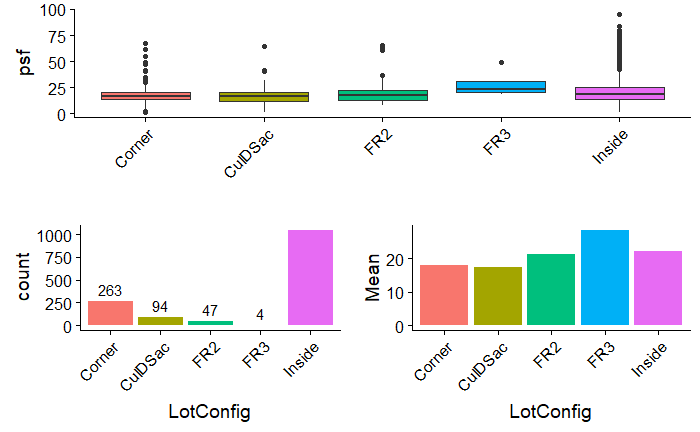

```r
factorChart(train, "LotConfig", "psf")
```

**Conclusion:** Not much to distinguish between Inside and corner. FR3 fetches good price ofcourse. But not enough values to conclude anything.

### LandSlope

**LandSlope:** Slope of property Gtl Gentle slope Mod Moderate Slope  
Sev Severe Slope

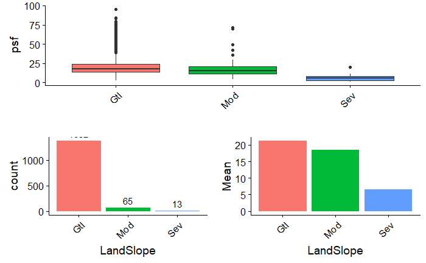

```r
factorChart(train, "LandSlope", "psf")
```

**Conclusion:** Probably realted with LandContour. gtl > mode > sev justified

### Neighborhood

**Neighborhood:** Physical locations within Ames city limits

```
   Blmngtn  Bloomington Heights
   Blueste  Bluestem
   BrDale   Briardale
   BrkSide  Brookside
   ClearCr  Clear Creek
   CollgCr  College Creek
   Crawfor  Crawford
   Edwards  Edwards
   Gilbert  Gilbert
   IDOTRR   Iowa DOT and Rail Road
   MeadowV  Meadow Village
   Mitchel  Mitchell
   Names    North Ames
   NoRidge  Northridge
   NPkVill  Northpark Villa
   NridgHt  Northridge Heights
   NWAmes   Northwest Ames
   OldTown  Old Town
   SWISU    South & West of Iowa State University
   Sawyer   Sawyer
   SawyerW  Sawyer West
   Somerst  Somerset
   StoneBr  Stone Brook
   Timber   Timberland
   Veenker  Veenker
```

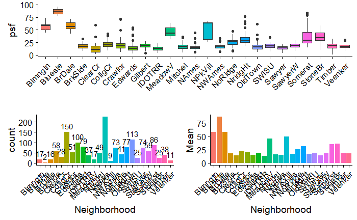

```r
factorChart(train, "Neighborhood", "psf")
```

**Conclusion:** Few neighborhood will be better. Looks important feature. We will explore it more at time of model creation.

### Condition1

**Condition1:** Proximity to various conditions

```
   Artery   Adjacent to arterial street
   Feedr    Adjacent to feeder street
   Norm Normal
   RRNn Within 200' of North-South Railroad
   RRAn Adjacent to North-South Railroad
   PosN Near positive off-site feature--park, greenbelt, etc.
   PosA Adjacent to postive off-site feature
   RRNe Within 200' of East-West Railroad
   RRAe Adjacent to East-West Railroad
```

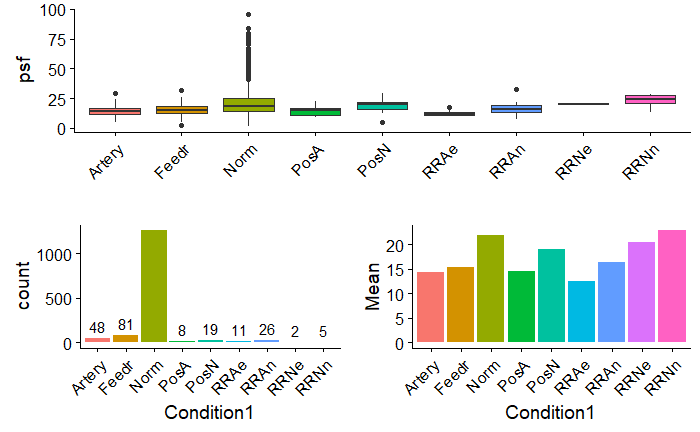

```r
factorChart(train, "Condition1", "psf")
```

**Conclustion:** People don’t like building adjacent to rail roads or streets.

### Condition2

**Condition2:** Proximity to various conditions (if more than one is present)

```
   Artery   Adjacent to arterial street
   Feedr    Adjacent to feeder street
   Norm Normal
   RRNn Within 200' of North-South Railroad
   RRAn Adjacent to North-South Railroad
   PosN Near positive off-site feature--park, greenbelt, etc.
   PosA Adjacent to postive off-site feature
   RRNe Within 200' of East-West Railroad
   RRAe Adjacent to East-West Railroad
```

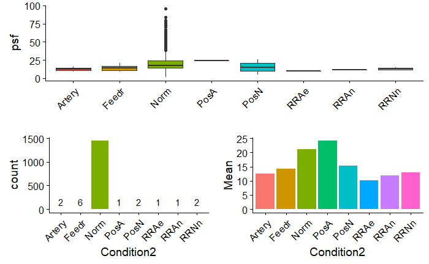

```r
factorChart(train, "Condition2", "psf")
```

**Conclusion:** Need to mix it with condition 1 to get better result

BldgType: Type of dwelling

> ```
>   1Fam    Single-family Detached
>   2FmCon  Two-family Conversion; originally built as one-family dwelling
>   Duplx   Duplex
>   TwnhsE  Townhouse End Unit
>   TwnhsI  Townhouse Inside Unit
> ```